# Report: Exploratory Data Analysis in Action - EDA: Number of attacks

### by Group: **Mittelbraun**

### We consist of 4 members:

- Robert Gaudin
- Joachim Buck
- Dennis Köser
- Christoffer Rubensson

### About this Report:

In this project we explored the [*Arial Bombing Data Set*](https://www.kaggle.com/usaf/world-war-ii) and applied techniques referred to as **Exploratory Data Analysis** and will answer questions about the number of air force attacks in Europe and Germany during WW2.

### Pre-Settings

**Import statements**

```python
import numpy as np
import pandas as pd
import matplotlib.pyplot as plt
import seaborn as sns
%matplotlib inline
```

**Global settings**

```python
pd.options.display.max_rows = 999
pd.options.display.max_columns = 100
plt.rcParams["figure.figsize"] = [15,6]
```

**Load data set**

```python
import pickle
gdf_europe = pickle.load( open( "../data/gdf_europe.p", "rb" ) )
europe = pickle.load( open( "../data/europe.p", "rb" ) )
```

**Create a copy of the data set**

```python
df_noa = gdf_europe.copy()
```

**Create a color set for the `print()` function:**

```python
class color:
   BOLD = '\033[1m'
   RED    = '\33[31m'
   UNDERLINE = '\033[4m'
   END = '\033[0m'
```

## Research questions

**@Number of attacks**

- Q1: How many attacks were launched between 1939 and 1945 over Europe?
- Q2: Which Allied Force was responsible for the most of the attacks? Did this change over time?
- Q3: Which Allied Force launched the most attacks against Germany?
- Q4: Is there a seasonal pattern in the attacks against Germany (e.g. winter vs. summer)?
- Q5: Which city (area) experienced the highest number of attacks? Did the area change over time?

> **Q1: How many attacks were launched between 1939 and 1945 over Europe?**

```python
atk = "{:,}".format(len(df_noa))

Q1 = "Between 1939 and 1945 there were {} attacks launched over Europe.".format(atk)
print(Q1)
```

```
Between 1939 and 1945 there were 120,068 attacks launched over Europe.
```

**Plot a graph**

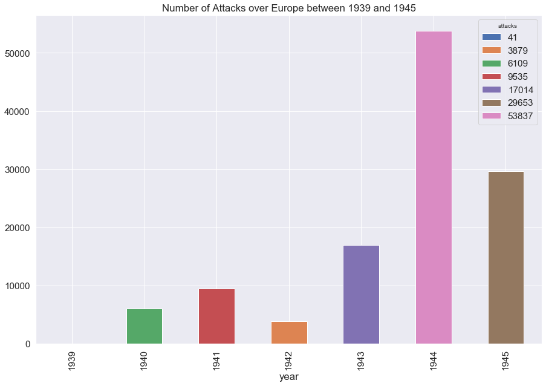

```python
total_attacks = len(df_noa)

#new data frame with attack year and number of attacks
def num_attacks():
    data = [[],[]]
    for i in range(1939,1946):
        data[0].append(i)
        df_noa_year = df_noa.loc[(df_noa.year == int(i))]
        attacks_year = len(df_noa_year)
        data[1].append(attacks_year)
        rows = zip(data[0], data[1])
        headers = ["year", "attacks"]
    return pd.DataFrame(rows, columns = headers)

df = num_attacks()
pivot_df = df.pivot(index = 'year', columns = 'attacks', values = 'attacks')
pivot_df.plot.bar(stacked=True, figsize=(15,10), title='Number of Attacks over Europe between 1939 and 1945')
```

> **Q2: Which Allied Force was responsible for the most of the attacks? Did this change over time?**

```python
country = df_noa["Country"].value_counts()[0:1].index.values[0]
attacks = df_noa["Country"].value_counts()[0]

Q2 = f"{country} was the country of the allied forces, which was responsible for the most attacks (" \
+ "{:,}".format(attacks) + ") between 1939 and 1945."

print(Q2)
```

```
USA was the country of the allied forces, which was responsible for the most attacks (43,095) between 1939 and 1945.
```

**Plot a graph**

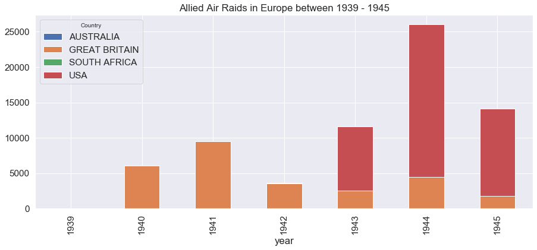

```python
number_oa = df_noa.groupby(["Country", "year"])["Country"].count().unstack("Country")
number_oa.plot(kind="bar",stacked=True, title = "Allied Air Raids in Europe between 1939 - 1945")
```

> **Q3: Which Allied Force launched the most attacks against Germany?**

```python
target_location = ["GERMANY"]
allied_location = ["GREAT BRITAIN", "USA"]

df_noa_subset=df_noa.loc[df_noa['Target Country'].isin(target_location) & df_noa["Country"].isin(allied_location)]
name = df_noa_subset.groupby(['Country'])['Target Country'].count().idxmax()

Q3 = name.title() + " was the country of the allied forces, which launched the most attacks against Germany in WW2."
print(Q3)
```

```
Great Britain was the country of the allied forces, which launched the most attacks against Germany in WW2.
```

**Plot a graph (bar)**

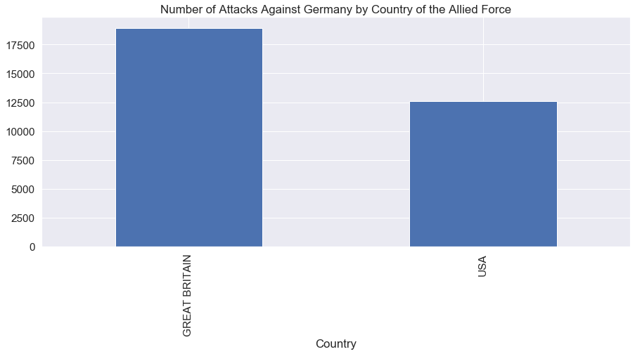

```python
gb = df_noa_subset.groupby(['Country'])['Target Country'].count()

gb.plot.bar(title="Number of Attacks Against Germany by Country of the Allied Force")
```

**Plot a graph (pie)**

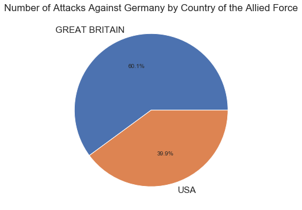

```python
gb.plot.pie(title="Number of Attacks Against Germany by Country of the Allied Force", autopct='%1.1f%%').set_ylabel("")
```

> **Q4: Is there a seasonal pattern in the attacks of the Allied Forces against Germany (e.g. winter vs. summer)?**